# Assignment 2

To be delivered until 2023/01/06 23:59:59.

## 1) Arduino

You will start by setting up a series of connections in order to extract some data with the Arduino. First make the connections as shown below. **Mind the direction of the temperature sensor. If you have an incorrect position, you will be connection the power to the ground and vice-versa and you will damage the sensor.** The photoresistor sensor on the other hand has no polarity.

[figure not shown]

On this problem, you will read temperature and luminance from the sensors and print them on the serial.

**1)** Code an Arduino sketch, where the value of temperature and luminance are printed to the serial. For each serial print that you make, print the value of temperature, then a semicolon, then the value of luminance with a new line (use no whitespaces). You can do this by using three separate `Serial.print`, with the last one being a `Serial.println`. Print values 5 times per second (use the delay function to control this). Manually influence the readings of the sensors, by covering the photoresistor or shining light on it, and by lightly and carefully touching the temperature sensor to increase its temperature readings.

**Note that the temperature sensor appears not to be very reliable. Since the objective of this exercise is just to plot the results, this should not be an issue.**

**Copy and paste your arduino code below. You may use a python code cell, even though the code can not be run.**

*Hint: for the temperature value to be in celsius, divide the read value by 1024 and multiply it by 500. The luminance does not have to be converted*

```python
int pintemp = A1;
int pinlum = A0;

void setup() {
    Serial.begin(9600);
}
void loop() {
    int temp = analogRead(pintemp);
    int lum = analogRead(pinlum);
    temp = temp*0.4882815;
    Serial.print(temp);
    Serial.print(";");
    Serial.println(lum);
    delay(200);
}
```

```python
import serial
import time

ser = serial.Serial('COM4', 9600, timeout=1)
time.sleep(2)

file = open('file1.txt', 'w')

for i in range(500):
    line = ser.readline()
    if line:
        string = line.decode()
        string = str(string)
        file.write(string)
        print(line)

ser.close()
file.close()
```

[output not shown]

[output cut: 445 more lines]

[output not shown]

Convert the data into a pandas dataframe and save it in a csv file. Besides the value of temperature and luminance, also include the time, considering the first observation at $t=0$ and every observation 0.2 seconds after the previous one. **The file must be submitted in Fenix and included in your Github repo**.

```python
import pandas as pd
import numpy as np

t = 0
time = []
temp = []
lum = []

file = open('file.txt', 'r')

lines = file.readlines()[::2]
sample_count = len(lines)

time = np.arange(0, sample_count*0.2, 0.2)

for line in lines:
    data = line.strip()
    data = data.split(';')

    temp.append(float(data[0]))
    lum.append(float(data[1]))

vectors = {'time':time, 'temperature':temp, 'luminance':lum}

df = pd.DataFrame(vectors, columns=['time', 'temperature', 'luminance'])
df.to_csv('data.csv', index=False)
```

Plot the Temperature against time, the luminance against time and the temperature against the luminance.

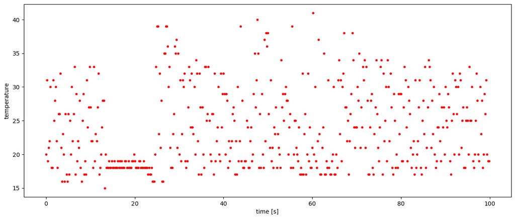

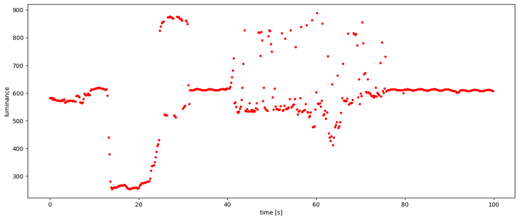

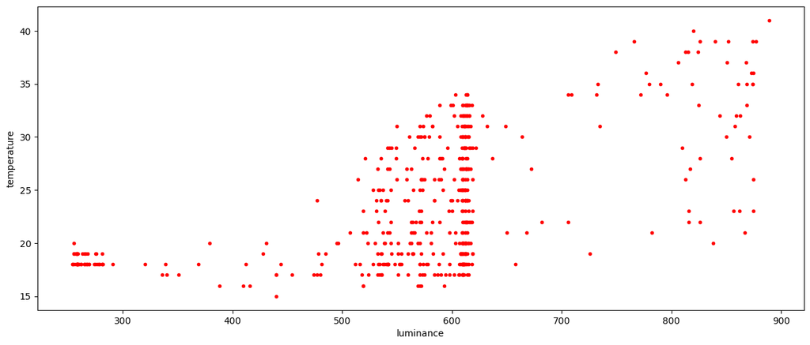

```python
import matplotlib.pyplot as plt

plt.rcParams['figure.figsize'] = [15, 6]
plt.xlabel("time [s]")
plt.ylabel("temperature")
plt.plot(df['time'], df['temperature'],'.r')
plt.show()

plt.rcParams['figure.figsize'] = [15, 6]
plt.xlabel("time [s]")
plt.ylabel("luminance")
plt.plot(df['time'], df['luminance'],'.r')
plt.show()

plt.rcParams['figure.figsize'] = [15, 6]
plt.xlabel("luminance")
plt.ylabel("temperature")
plt.plot(df['luminance'], df['temperature'],'.r')
plt.show()
```

## 2) Databases

For the databases part of this assignment, you will use the mimic-iii database from the laboratory session. Start by adding a few new tables to the database, using the SQL files included in the assignment's files. Open PGAdmin and connect to your mimic-iii database. **To properly load these tables, load the following files exactly and by the order presented.**

1. Run demographic.sql
2. Run lab_firstday.sql

You will now have to answer a few SQL questions.

**1.** Open the connection to your mimic-iii database. If you want, you can delete your credentials before submitting the assignment, but if you do so, please run the notebook first, for the results to be displayed.

```python
#Import required libraries
import psycopg2 as psql
import pandas as pd

#Define function to conncet to a specified databse
def connect(datab):
    conn = psql.connect(host='localhost',
                        database = datab,
                        user='postgres',
                        password='*****',
                        port=5432)

    #Create a cursor object using the cursor() method
    cursor = conn.cursor()

    #Execute a SQL function using the execute() method
    cursor.execute("select version()")

    # Fetch a single row using fetchone() method
    data = cursor.fetchone()
    print("Connection established to: ", data)

    #Return conn varaible
    return conn

connect('mimic-iii')
```

```
Connection established to:  ('PostgreSQL 15.1, compiled by Visual C++ build 1914, 64-bit',)
```

```
<connection object at 0x0000018C0D4846A0; dsn: 'user=postgres password=xxx dbname=mimic-iii host=localhost port=5432', closed: 0>
```

**2.** Create a function that receives an SQL query and automatically opens a cursor, queries the database, extracts the columns, creates a pandas database, and closes the connections.

```python
#Define function
def auto_query(query, database):
    #Get conn cariable from specific database
    conn = connect(database)

    #Create a cursor object using the cursor() method
    cursor = conn.cursor()

    #Execute a SQL function using the execute() method
    cursor.execute(query)

    #Extract the column names and obtain the data from the cursor
    colnames = [desc[0] for desc in cursor.description]
    data = cursor.fetchall()

    #Creat a pandas database
    table = pd.DataFrame(data, columns = colnames)

    #Close the connection
    conn.close()

    #Displays the table
    return table
```

**3.** Query the table admissions filtering for admission type as emergency and insurance as private.

```python
#Define query
query = "SELECT * FROM public.admissions " +\
        "WHERE admission_type = 'EMERGENCY' AND insurance = 'Private'"

#Execute auto_query function
auto_query(query, 'mimic-iii')
```

```
Connection established to:  ('PostgreSQL 15.1, compiled by Visual C++ build 1914, 64-bit',)
```

|  | row_id | subject_id | hadm_id | admittime | dischtime | deathtime | admission_type | admission_location | discharge_location | insurance | language | religion | marital_status | ethnicity | edregtime | edouttime | diagnosis | hospital_expire_flag | has_chartevents_data |
| --- | --- | --- | --- | --- | --- | --- | --- | --- | --- | --- | --- | --- | --- | --- | --- | --- | --- | --- | --- |
| 0 | 12263 | 10011 | 105331 | 2126-08-14 22:32:00 | 2126-08-28 18:59:00 | 2126-08-28 18:59:00 | EMERGENCY | TRANSFER FROM HOSP/EXTRAM | DEAD/EXPIRED | Private | None | CATHOLIC | SINGLE | UNKNOWN/NOT SPECIFIED | NaT | NaT | HEPATITIS B | 1 | 1 |
| 1 | 12317 | 10067 | 160442 | 2130-10-06 01:34:00 | 2130-10-06 02:29:00 | 2130-10-06 02:29:00 | EMERGENCY | EMERGENCY ROOM ADMIT | DEAD/EXPIRED | Private | None | UNOBTAINABLE | None | OTHER | 2130-10-06 00:12:00 | 2130-10-06 01:30:00 | S/P MOTORCYCLE ACCIDENT | 1 | 1 |
| 2 | 12339 | 10088 | 149044 | 2107-05-12 18:00:00 | 2107-05-18 13:30:00 | NaT | EMERGENCY | TRANSFER FROM HOSP/EXTRAM | SNF | Private | None | UNOBTAINABLE | UNKNOWN (DEFAULT) | WHITE | NaT | NaT | UROSEPSIS | 0 | 1 |
| 3 | 12341 | 10090 | 176805 | 2124-01-12 14:26:00 | 2124-01-14 19:00:00 | NaT | EMERGENCY | EMERGENCY ROOM ADMIT | DISCH-TRAN TO PSYCH HOSP | Private | ENGL | NOT SPECIFIED | SINGLE | WHITE | 2124-01-12 11:56:00 | 2124-01-12 16:09:00 | OVERDOSE | 0 | 1 |
| 4 | 12349 | 10098 | 180685 | 2170-12-02 23:24:00 | 2170-12-03 15:55:00 | 2170-12-03 15:55:00 | EMERGENCY | EMERGENCY ROOM ADMIT | DEAD/EXPIRED | Private | None | UNOBTAINABLE | None | OTHER | 2170-12-02 22:45:00 | 2170-12-03 00:56:00 | STATUS POST MOTOR VEHICLE ACCIDENT WITH INJURIES | 1 | 1 |
| 5 | 12357 | 10106 | 133283 | 2161-09-14 22:22:00 | 2161-09-19 17:00:00 | NaT | EMERGENCY | EMERGENCY ROOM ADMIT | HOME WITH HOME IV PROVIDR | Private | None | CATHOLIC | MARRIED | WHITE | 2161-09-14 14:45:00 | 2161-09-15 01:30:00 | HEADACHE | 0 | 1 |
| 6 | 12368 | 10117 | 187023 | 2138-06-05 17:23:00 | 2138-06-11 10:16:00 | NaT | EMERGENCY | EMERGENCY ROOM ADMIT | HOME | Private | None | CATHOLIC | SINGLE | UNKNOWN/NOT SPECIFIED | 2138-06-05 11:42:00 | 2138-06-05 21:20:00 | FEVER | 0 | 1 |
| 7 | 12369 | 10117 | 105150 | 2138-11-09 18:08:00 | 2138-11-18 23:13:00 | 2138-11-18 23:13:00 | EMERGENCY | EMERGENCY ROOM ADMIT | DEAD/EXPIRED | Private | None | CATHOLIC | SINGLE | UNKNOWN/NOT SPECIFIED | 2138-11-09 15:42:00 | 2138-11-09 20:42:00 | FEVER | 1 | 1 |
| 8 | 12381 | 10126 | 160445 | 2171-07-12 06:02:00 | 2171-08-16 12:00:00 | 2171-08-16 12:00:00 | EMERGENCY | PHYS REFERRAL/NORMAL DELI | DEAD/EXPIRED | Private | None | UNOBTAINABLE | SINGLE | WHITE | NaT | NaT | LIVER FAILURE | 1 | 1 |
| 9 | 12382 | 10127 | 182839 | 2198-06-28 05:34:00 | 2198-07-20 14:56:00 | NaT | EMERGENCY | EMERGENCY ROOM ADMIT | REHAB/DISTINCT PART HOSP | Private | None | NOT SPECIFIED | None | WHITE | 2198-06-28 04:28:00 | 2198-06-28 05:52:00 | S/P MOTOR VEHICLE ACCIDENT | 0 | 1 |
| 10 | 12385 | 10130 | 156668 | 2161-01-30 16:26:00 | 2161-02-19 14:05:00 | NaT | EMERGENCY | EMERGENCY ROOM ADMIT | HOME HEALTH CARE | Private | None | CATHOLIC | MARRIED | UNKNOWN/NOT SPECIFIED | 2161-01-30 10:35:00 | 2161-01-30 20:25:00 | ABSCESS | 0 | 1 |
| 11 | 39869 | 40310 | 186361 | 2144-07-11 15:02:00 | 2144-11-12 14:40:00 | NaT | EMERGENCY | TRANSFER FROM HOSP/EXTRAM | REHAB/DISTINCT PART HOSP | Private | ENGL | CATHOLIC | SINGLE | WHITE | NaT | NaT | FACIAL NUMBNESS | 0 | 1 |
| 12 | 39962 | 40601 | 182879 | 2184-08-04 05:44:00 | 2184-08-10 15:30:00 | NaT | EMERGENCY | EMERGENCY ROOM ADMIT | SNF | Private | ENGL | PROTESTANT QUAKER | MARRIED | WHITE | 2184-08-04 01:35:00 | 2184-08-04 06:47:00 | SEPSIS | 0 | 1 |
| 13 | 40440 | 42066 | 171628 | 2112-02-04 14:49:00 | 2112-02-11 12:00:00 | 2112-02-11 12:00:00 | EMERGENCY | TRANSFER FROM HOSP/EXTRAM | DEAD/EXPIRED | Private | ENGL | CATHOLIC | SINGLE | WHITE | NaT | NaT | TRACHEAL STENOSIS | 1 | 1 |
| 14 | 40512 | 42292 | 138503 | 2162-01-16 13:56:00 | 2162-01-19 13:45:00 | NaT | EMERGENCY | EMERGENCY ROOM ADMIT | HOME | Private | ENGL | CATHOLIC | SINGLE | WHITE | 2162-01-16 11:28:00 | 2162-01-16 16:12:00 | PNEUMONIA/HYPOGLCEMIA/SYNCOPE | 0 | 1 |
| 15 | 40993 | 43881 | 172454 | 2104-09-24 17:31:00 | 2104-09-30 16:17:00 | NaT | EMERGENCY | EMERGENCY ROOM ADMIT | HOME HEALTH CARE | Private | ENGL | NOT SPECIFIED | MARRIED | WHITE | 2104-09-24 12:07:00 | 2104-09-24 18:50:00 | ACUTE PULMONARY EMBOLISM | 0 | 1 |
| 16 | 40994 | 43881 | 167021 | 2104-10-24 09:44:00 | 2104-11-01 11:59:00 | NaT | EMERGENCY | EMERGENCY ROOM ADMIT | HOME | Private | ENGL | NOT SPECIFIED | MARRIED | WHITE | 2104-10-24 07:17:00 | 2104-10-24 11:10:00 | UPPER GI BLEED | 0 | 1 |
| 17 | 41054 | 44083 | 131048 | 2112-05-22 15:37:00 | 2112-05-25 13:30:00 | NaT | EMERGENCY | EMERGENCY ROOM ADMIT | HOME HEALTH CARE | Private | ENGL | CATHOLIC | SINGLE | WHITE | 2112-05-22 09:25:00 | 2112-05-22 17:04:00 | SHORTNESS OF BREATH | 0 | 1 |
| 18 | 41055 | 44083 | 198330 | 2112-05-28 15:45:00 | 2112-06-07 16:50:00 | NaT | EMERGENCY | EMERGENCY ROOM ADMIT | HOME | Private | ENGL | CATHOLIC | SINGLE | WHITE | 2112-05-28 13:16:00 | 2112-05-28 17:30:00 | PERICARDIAL EFFUSION | 0 | 1 |
| 19 | 41092 | 44228 | 103379 | 2170-12-15 03:14:00 | 2170-12-24 18:00:00 | NaT | EMERGENCY | EMERGENCY ROOM ADMIT | HOME HEALTH CARE | Private | ENGL | NOT SPECIFIED | SINGLE | WHITE | 2170-12-15 02:22:00 | 2170-12-15 05:25:00 | CHOLANGITIS | 0 | 1 |

**4.** Query the table admissions, filtering for the same conditions as the previous exercise (admission type as emergency and insurance as private). Join the "drgcodes" table on the admission ID. Display only the columns regarding the subject id, admission id, time of death, and description of the drug.

```python
#Define query
query=  "SELECT * FROM public.admissions " +\
        "LEFT JOIN public.drgcodes " +\
        "ON public.admissions.hadm_id = public.drgcodes.hadm_id " +\
        "WHERE admission_type = 'EMERGENCY' AND insurance = 'Private'"

#Execute auto_query function
table = auto_query(query, 'mimic-iii')

#Filter the obtained table
keep_cols = ['subject_id', 'hadm_id', 'deathtime', 'description']
table_filtered = table[keep_cols]

#Remove duplicated subject_id and hadm_id
table_filtered = table_filtered.iloc[:,list(set(range(table_filtered.shape[1])) - set([1, 3]))]

#Displays final table
table_filtered
```

```
Connection established to:  ('PostgreSQL 15.1, compiled by Visual C++ build 1914, 64-bit',)
```

|  | subject_id | hadm_id | deathtime | description |
| --- | --- | --- | --- | --- |
| 0 | 10130 | 156668 | NaT | MAJOR SMALL & LARGE BOWEL PROCEDURES WITH COMP... |
| 1 | 10117 | 187023 | NaT | DENTAL & ORAL DIS EXCEPT EXTRACTIONS & RESTORA... |
| 2 | 10011 | 105331 | 2126-08-28 18:59:00 | DISORDERS OF LIVER EXCEPT MALIGNANCY, CIRRHOSI... |
| 3 | 10117 | 105150 | 2138-11-18 23:13:00 | SIMPLE PNEUMONIA & PLEURISY AGE >17 WITH COMPL... |
| 4 | 10106 | 133283 | NaT | NERVOUS SYSTEM INFECTION EXCEPT VIRAL MENINGITIS |
| 5 | 10126 | 160445 | 2171-08-16 12:00:00 | Liver Transplant |
| 6 | 10126 | 160445 | 2171-08-16 12:00:00 | ECMO OR TRACHEOSTOMY WITH MECHANICAL VENTILATI... |
| 7 | 10088 | 149044 | NaT | SEPTICEMIA AGE >17 |
| 8 | 10098 | 180685 | 2170-12-03 15:55:00 | Craniotomy for Trauma |
| 9 | 10098 | 180685 | 2170-12-03 15:55:00 | CRANIOTOMY AGE >17 WITH COMPLICATIONS, COMORBI... |
| 10 | 10067 | 160442 | 2130-10-06 02:29:00 | OTHER OPERATING ROOM PROCEDURES FOR MULTIPLE S... |
| 11 | 10127 | 182839 | NaT | ECMO OR TRACHEOSTOMY WITH MECHANICAL VENTILATI... |
| 12 | 10127 | 182839 | NaT | Musculoskeletal & Other Procedures For Multipl... |
| 13 | 10090 | 176805 | NaT | POISONING & TOXIC EFFECTS OF DRUGS AGE >17 WIT... |
| 14 | 10090 | 176805 | NaT | Poisoning Of Medicinal Agents |
| 15 | 43881 | 172454 | NaT | Pulmonary Embolism |
| 16 | 43881 | 172454 | NaT | Pulmonary Embolism |
| 17 | 43881 | 172454 | NaT | PULMONARY EMBOLISM W MCC |
| 18 | 43881 | 167021 | NaT | Digestive Malignancy |
| 19 | 43881 | 167021 | NaT | Digestive Malignancy |
| 20 | 43881 | 167021 | NaT | OTHER DIGESTIVE SYSTEM O.R. PROCEDURES W MCC |
| 21 | 44228 | 103379 | NaT | Septicemia & Disseminated Infections |
| 22 | 44228 | 103379 | NaT | Septicemia & Disseminated Infections |
| 23 | 44228 | 103379 | NaT | SEPTICEMIA OR SEVERE SEPSIS W/O MV 96+ HOURS W... |
| 24 | 42292 | 138503 | NaT | Contusion, Open Wound & Other Trauma To Skin &... |
| 25 | 42292 | 138503 | NaT | Contusion, Open Wound & Other Trauma To Skin &... |
| 26 | 42292 | 138503 | NaT | TRAUMA TO THE SKIN, SUBCUT TISS & BREAST W MCC |
| 27 | 44083 | 198330 | NaT | Other Circulatory System Procedures |
| 28 | 44083 | 198330 | NaT | Other Circulatory System Procedures |
| 29 | 44083 | 198330 | NaT | MAJOR CARDIOVASC PROCEDURES W/O MCC |
| 30 | 40310 | 186361 | NaT | Other O.R. Procedures For Lymphatic/Hematopiet... |
| 31 | 40310 | 186361 | NaT | Other O.R. Procedures For Lymphatic/Hematopiet... |
| 32 | 40310 | 186361 | NaT | LYMPHOMA & NON-ACUTE LEUKEMIA W OTHER O.R. PRO... |
| 33 | 44083 | 131048 | NaT | Other Respiratory Diagnosis Except Signs, Symp... |
| 34 | 44083 | 131048 | NaT | Other Respiratory Diagnosis Except Signs, Symp... |
| 35 | 44083 | 131048 | NaT | PLEURAL EFFUSION W CC |
| 36 | 40601 | 182879 | NaT | Acute Myocardial Infarction |
| 37 | 40601 | 182879 | NaT | Acute Myocardial Infarction |
| 38 | 40601 | 182879 | NaT | ACUTE MYOCARDIAL INFARCTION, DISCHARGED ALIVE ... |
| 39 | 42066 | 171628 | 2112-02-11 12:00:00 | Respiratory System Diagnosis w/ Ventilator Sup... |
| 40 | 42066 | 171628 | 2112-02-11 12:00:00 | Respiratory System Diagnosis w/ Ventilator Sup... |
| 41 | 42066 | 171628 | 2112-02-11 12:00:00 | RESPIRATORY SYSTEM DIAGNOSIS W VENTILATOR SUPP... |

**5.1.** Obtain the dataset for this problem, by running the SQL query below.

```python
query = "SELECT pivoted_lab.*," +\
                "gender as gender," +\
                "admission_age," +\
                "ethnicity_grouped as eth_grp," +\
                "hospital_expire_flag," +\
                "los_icu " +\
        "FROM demographics " +\
        "LEFT JOIN pivoted_lab " +\
        "ON demographics.icustay_id = pivoted_lab.icustay_id " +\
        "WHERE first_icu_stay = true"

dataset1 = auto_query(query, 'mimic-iii')

dataset1
```

```
Connection established to:  ('PostgreSQL 15.1, compiled by Visual C++ build 1914, 64-bit',)
```

|  | subject_id | hadm_id | icustay_id | aniongap_min | aniongap_max | albumin_min | albumin_max | bands_min | bands_max | bicarbonate_min | ... | sodium_max | bun_min | bun_max | wbc_min | wbc_max | gender | admission_age | eth_grp | hospital_expire_flag | los_icu |
| --- | --- | --- | --- | --- | --- | --- | --- | --- | --- | --- | --- | --- | --- | --- | --- | --- | --- | --- | --- | --- | --- |
| 0 | 10006 | 142345 | 206504 | 12.0 | 20.0 | 2.7 | 3.4 | NaN | NaN | 29.0 | ... | 139.0 | 9.0 | 11.0 | 4.6 | 7.8 | F | 70.0 | black | 0 | 1.0 |
| 1 | 10011 | 105331 | 232110 | 12.0 | 12.0 | 2.6 | 2.6 | 2.0 | 2.0 | 23.0 | ... | 136.0 | 3.0 | 3.0 | 10.6 | 10.6 | F | 36.0 | unknown | 1 | 13.0 |
| 2 | 10013 | 165520 | 264446 | 13.0 | 13.0 | NaN | NaN | 13.0 | 13.0 | 29.0 | ... | 138.0 | 32.0 | 32.0 | 13.8 | 16.2 | F | 87.0 | unknown | 1 | 2.0 |
| 3 | 10017 | 199207 | 204881 | 13.0 | 13.0 | 2.8 | 2.8 | NaN | NaN | 29.0 | ... | 139.0 | 3.0 | 3.0 | 15.8 | 15.8 | F | 74.0 | white | 0 | 2.0 |
| 4 | 10019 | 177759 | 228977 | 20.0 | 46.0 | 3.2 | 3.2 | NaN | NaN | 10.0 | ... | 141.0 | 31.0 | 53.0 | 3.7 | 6.8 | M | 49.0 | white | 1 | 1.0 |
| ... | ... | ... | ... | ... | ... | ... | ... | ... | ... | ... | ... | ... | ... | ... | ... | ... | ... | ... | ... | ... | ... |
| 123 | 44083 | 198330 | 286428 | 16.0 | 16.0 | NaN | NaN | NaN | NaN | 21.0 | ... | 142.0 | 12.0 | 12.0 | 12.3 | 14.9 | M | 55.0 | white | 0 | 3.0 |
| 124 | 44154 | 174245 | 217724 | 15.0 | 15.0 | NaN | NaN | NaN | NaN | 19.0 | ... | 142.0 | 16.0 | 21.0 | 12.2 | 17.1 | M | 300.0 | white | 1 | 0.0 |
| 125 | 44212 | 163189 | 239396 | 15.0 | 21.0 | 2.9 | 3.0 | NaN | NaN | 18.0 | ... | 150.0 | 37.0 | 57.0 | 8.8 | 11.4 | F | 45.0 | black | 0 | 31.0 |
| 126 | 44222 | 192189 | 238186 | 11.0 | 15.0 | NaN | NaN | NaN | NaN | 22.0 | ... | 135.0 | 21.0 | 24.0 | 9.3 | 9.9 | M | 73.0 | white | 0 | 1.0 |
| 127 | 44228 | 103379 | 217992 | 12.0 | 18.0 | 2.2 | 2.7 | NaN | NaN | 15.0 | ... | 142.0 | 10.0 | 11.0 | 7.0 | 41.9 | F | 58.0 | white | 0 | 4.0 |

128 rows × 46 columns

**5.2.** Close the connection to your SQL server.

```python
#NOTE: The connection is automatically colsed when executing auto_query function.
conn.close()
```

**5.3.** Prepare your dataset:

- Drop the ID columns of subject, admission and ICU stay.
- Drop columns with at least one NA value.
- Encode the categorical columns, the ethnicity and gender ('eth_grp', 'gender'). *Suggestion: use pd.get_dummies*
- Consider the column 'hospital_expire_flag' as the response and all remaining columns as the predictors.

```python
#Drop the ID columns of subject, admission and ICU stay
dataset = dataset1.drop(columns = ['subject_id','hadm_id','icustay_id'])

#Drop NaN Columns
dataset = dataset.dropna(axis=1)

#Encode categories
dummies = pd.get_dummies(dataset[['eth_grp', 'gender']])
dataset = dataset.drop(columns=['eth_grp', 'gender'])

#Create Final DataSet
dataset = pd.concat([dataset, dummies], axis=1)
dataset.head()

#Display final dataset
dataset
```

|  | bicarbonate_min | bicarbonate_max | creatinine_min | creatinine_max | chloride_min | chloride_max | glucose_min | glucose_max | hematocrit_min | hematocrit_max | ... | los_icu | eth_grp_asian | eth_grp_black | eth_grp_hispanic | eth_grp_native | eth_grp_other | eth_grp_unknown | eth_grp_white | gender_F | gender_M |
| --- | --- | --- | --- | --- | --- | --- | --- | --- | --- | --- | --- | --- | --- | --- | --- | --- | --- | --- | --- | --- | --- |
| 0 | 29.0 | 31.0 | 3.0 | 3.5 | 96.0 | 100.0 | 84.0 | 217.0 | 36.9 | 42.4 | ... | 1.0 | 0 | 1 | 0 | 0 | 0 | 0 | 0 | 1 | 0 |
| 1 | 23.0 | 23.0 | 0.7 | 0.7 | 107.0 | 107.0 | 79.0 | 79.0 | 33.9 | 34.0 | ... | 13.0 | 0 | 0 | 0 | 0 | 0 | 1 | 0 | 1 | 0 |
| 2 | 29.0 | 29.0 | 1.7 | 1.7 | 98.0 | 100.0 | 134.0 | 165.0 | 28.1 | 29.2 | ... | 2.0 | 0 | 0 | 0 | 0 | 0 | 1 | 0 | 1 | 0 |
| 3 | 29.0 | 29.0 | 0.3 | 0.3 | 100.0 | 100.0 | 137.0 | 137.0 | 27.5 | 27.5 | ... | 2.0 | 0 | 0 | 0 | 0 | 0 | 0 | 1 | 1 | 0 |
| 4 | 10.0 | 18.0 | 4.0 | 7.2 | 83.0 | 104.0 | 80.0 | 360.0 | 30.6 | 36.0 | ... | 1.0 | 0 | 0 | 0 | 0 | 0 | 0 | 1 | 0 | 1 |
| ... | ... | ... | ... | ... | ... | ... | ... | ... | ... | ... | ... | ... | ... | ... | ... | ... | ... | ... | ... | ... | ... |
| 123 | 21.0 | 21.0 | 0.7 | 0.7 | 108.0 | 108.0 | 151.0 | 151.0 | 26.0 | 29.0 | ... | 3.0 | 0 | 0 | 0 | 0 | 0 | 0 | 1 | 0 | 1 |
| 124 | 19.0 | 19.0 | 0.9 | 0.9 | 107.0 | 113.0 | 164.0 | 177.0 | 40.8 | 41.8 | ... | 0.0 | 0 | 0 | 0 | 0 | 0 | 0 | 1 | 0 | 1 |
| 125 | 18.0 | 23.0 | 3.0 | 4.8 | 108.0 | 115.0 | 99.0 | 122.0 | 23.8 | 25.9 | ... | 31.0 | 0 | 1 | 0 | 0 | 0 | 0 | 0 | 1 | 0 |
| 126 | 22.0 | 27.0 | 1.2 | 1.7 | 100.0 | 101.0 | 56.0 | 268.0 | 37.8 | 39.0 | ... | 1.0 | 0 | 0 | 0 | 0 | 0 | 0 | 1 | 0 | 1 |
| 127 | 15.0 | 24.0 | 0.6 | 0.8 | 103.0 | 115.0 | 91.0 | 132.0 | 22.6 | 27.6 | ... | 4.0 | 0 | 0 | 0 | 0 | 0 | 0 | 1 | 1 | 0 |

128 rows × 32 columns

**6.** Fit the following tree-based classifiers to the dataset. For each method:

- Perform k-fold cross validation to evaluate the models. Consider 10 folds.
- Plot the ROC curves for each fold, along with the mean ROC curve.
- Calculate the mean AUC.

**a.** Decision tree.

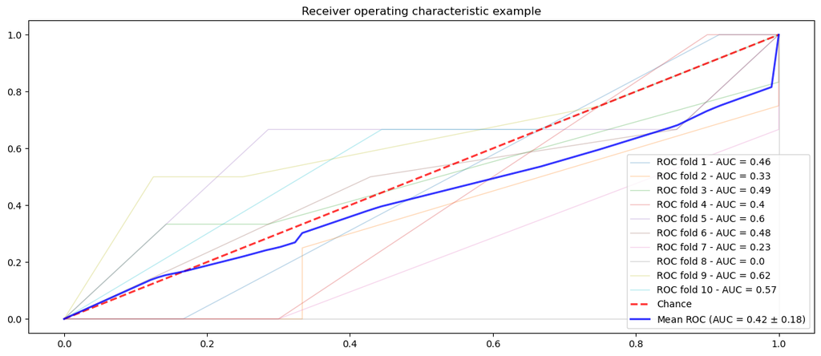

```python
from sklearn.model_selection import KFold
from sklearn.model_selection import train_test_split, KFold
from sklearn.tree import DecisionTreeClassifier, DecisionTreeRegressor, export_graphviz
from sklearn.ensemble import RandomForestClassifier, GradientBoostingClassifier, RandomForestRegressor, GradientBoostingRegressor
from sklearn.metrics import confusion_matrix, mean_squared_error, auc, roc_curve

#Divide Data
y = dataset.hospital_expire_flag
X = dataset.drop(['hospital_expire_flag'], axis = 1)

#Cross validation
kfold = KFold(n_splits=10, shuffle=True, random_state=0)

#Decision Tree Classifier
clf_dt = DecisionTreeClassifier(max_depth=5)

tprs = []
aucs = []

mean_fpr = np.linspace(0,1,100)

fig, ax = plt.subplots()

for i, (train,test) in enumerate(kfold.split(X,y)):
    clf_dt.fit(X.loc[train], y[train])
    y_proba = clf_dt.predict_proba(X.loc[test])
    fpr, tpr, _ = roc_curve(y[test], y_proba[:,1])

    interp_tpr = np.interp(mean_fpr, fpr, tpr)
    interp_tpr[0] = 0.0

    tprs.append(interp_tpr)
    aucs.append(auc(fpr,tpr))

    ax.plot(fpr, tpr, label='ROC fold ' + str(i+1) + ' - AUC = ' + str(np.round(auc(fpr,tpr),2)), lw=1, alpha=0.3)

# Plot mean roc curve auc
ax.plot([0, 1], [0, 1], linestyle="--", lw=2, color="r", label="Chance", alpha=0.8)

mean_tpr = np.mean(tprs, axis=0)
mean_tpr[-1] = 1.0
mean_auc = auc(mean_fpr, mean_tpr)
std_auc = np.std(aucs)

ax.plot(mean_fpr, mean_tpr, color="b", label=r"Mean ROC (AUC = %0.2f $\pm$ %0.2f)" % (mean_auc, std_auc), lw=2, alpha=0.8)

ax.set(xlim=[-0.05, 1.05], ylim=[-0.05, 1.05], title="Receiver operating characteristic example")

ax.legend(loc="lower right")
plt.show()
```

**b.** Random forest

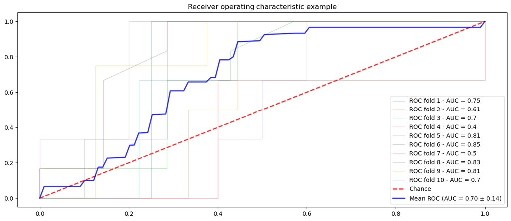

```python
# Random Forest Classifier
clf_rfc = RandomForestClassifier(n_estimators=200, random_state=0)

tprs = []
aucs = []

mean_fpr = np.linspace(0,1,100)

fig, ax = plt.subplots()

for i, (train,test) in enumerate(kfold.split(X,y)):
    clf_rfc.fit(X.loc[train], y[train])
    y_proba = clf_rfc.predict_proba(X.loc[test])
    fpr, tpr, _ = roc_curve(y[test], y_proba[:,1])

    interp_tpr = np.interp(mean_fpr, fpr, tpr)
    interp_tpr[0] = 0.0

    tprs.append(interp_tpr)
    aucs.append(auc(fpr,tpr))

    ax.plot(
    fpr, tpr,
    label='ROC fold ' + str(i+1) + ' - AUC = ' + str(np.round(auc(fpr,tpr),2)),
    lw=1,
    alpha=0.3)

# Plot mean roc curve auc
ax.plot([0, 1], [0, 1], linestyle="--", lw=2, color="r", label="Chance", alpha=0.8)

mean_tpr = np.mean(tprs, axis=0)
mean_tpr[-1] = 1.0
mean_auc = auc(mean_fpr, mean_tpr)
std_auc = np.std(aucs)

ax.plot(mean_fpr, mean_tpr, color="b", label=r"Mean ROC (AUC = %0.2f $\pm$ %0.2f)" % (mean_auc, std_auc), lw=2, alpha=0.8)

ax.set(xlim=[-0.05, 1.05], ylim=[-0.05, 1.05], title="Receiver operating characteristic example")

ax.legend(loc="lower right")
plt.show()
```

**c.** Gradient Boosting

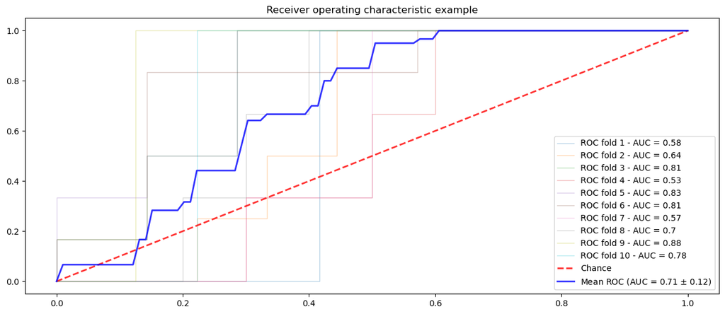

```python
gbr = GradientBoostingRegressor(n_estimators = 500, learning_rate = 0.01, max_depth = 2, random_state = 1)

tprs = []
aucs = []

mean_fpr = np.linspace(0,1,100)

fig, ax = plt.subplots()

for i, (train,test) in enumerate(kfold.split(X,y)):
    gbr.fit(X.loc[train], y[train])
    y_proba = gbr.predict(X.loc[test])
    fpr, tpr, _ = roc_curve(y[test], y_proba[:])

    interp_tpr = np.interp(mean_fpr, fpr, tpr)
    interp_tpr[0] = 0.0

    tprs.append(interp_tpr)
    aucs.append(auc(fpr,tpr))

    ax.plot(fpr, tpr, label='ROC fold ' + str(i+1) + ' - AUC = ' + str(np.round(auc(fpr,tpr),2)), lw=1, alpha=0.3)

# Plot mean roc curve auc
ax.plot([0, 1], [0, 1], linestyle="--", lw=2, color="r", label="Chance", alpha=0.8)

mean_tpr = np.mean(tprs, axis=0)
mean_tpr[-1] = 1.0
mean_auc = auc(mean_fpr, mean_tpr)
std_auc = np.std(aucs)

ax.plot(mean_fpr, mean_tpr, color="b", label=r"Mean ROC (AUC = %0.2f $\pm$ %0.2f)" % (mean_auc, std_auc), lw=2, alpha=0.8)

ax.set(xlim=[-0.05, 1.05], ylim=[-0.05, 1.05], title="Receiver operating characteristic example")

ax.legend(loc="lower right")
plt.show()
```

**7.1.** Perform a grid search cross-validation on the Gradient boosting methods, changing the value of the learning rate (0.01 to 0.5) and the number of estimators (50-500). Consider the mean AUC of the folds as the performance measure.

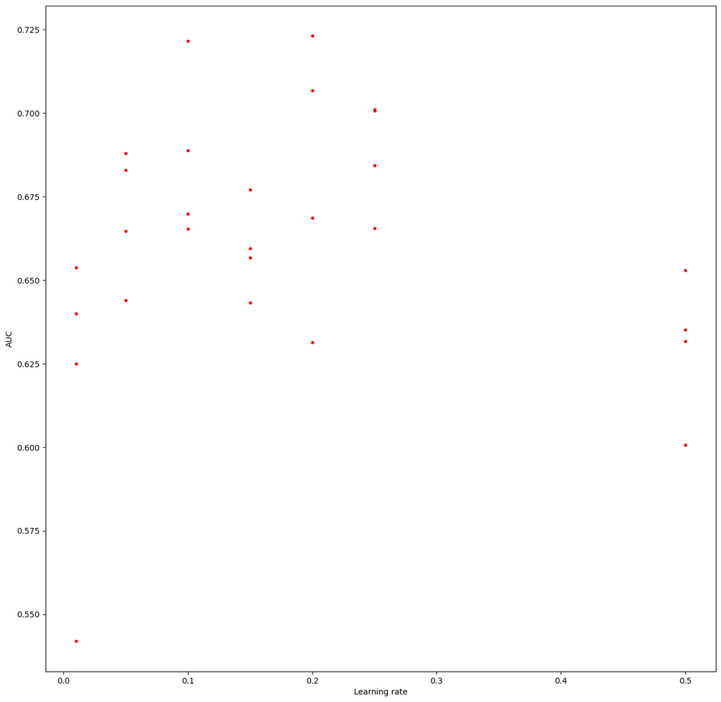

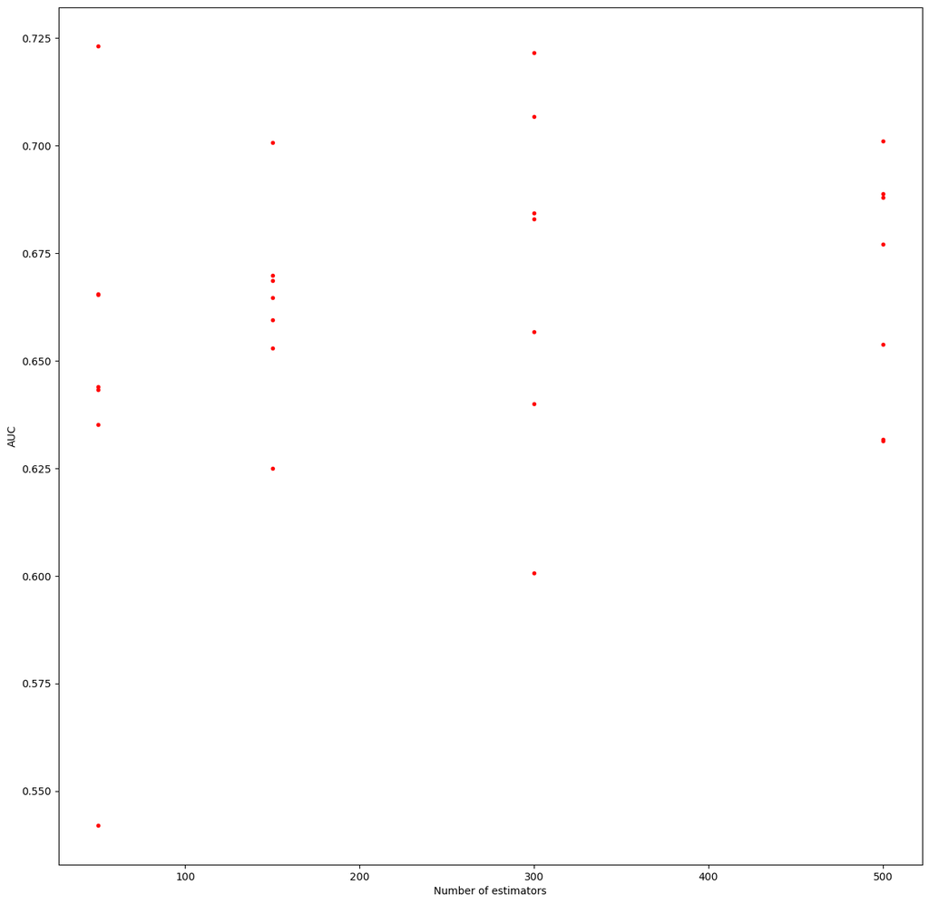

```python
from sklearn.model_selection import GridSearchCV

X_train, X_test, y_train, y_test = train_test_split(X, y, train_size = 0.7, random_state = 0)

tuned_parameters = [{'learning_rate': [0.01, 0.05, 0.1, 0.15, 0.2, 0.25, 0.5] , 'n_estimators':[50 ,150, 300, 500]}]
clf = GridSearchCV(GradientBoostingRegressor(), tuned_parameters, cv=10, scoring='roc_auc')
clf.fit(X_train,y_train)

cv_results = pd.DataFrame(clf.cv_results_)


plt.plot(cv_results['param_learning_rate'], cv_results['mean_test_score'],'.r')
plt.xlabel('Learning rate')
plt.ylabel('AUC')
plt.show()

plt.plot(cv_results['param_n_estimators'], cv_results['mean_test_score'],'.r')
plt.xlabel('Number of estimators')
plt.ylabel('AUC')
plt.show()
```

**7.2.** Plot a scatterplot of the learning rate versus the number of estimators, with the mean AUC as the color gradient.

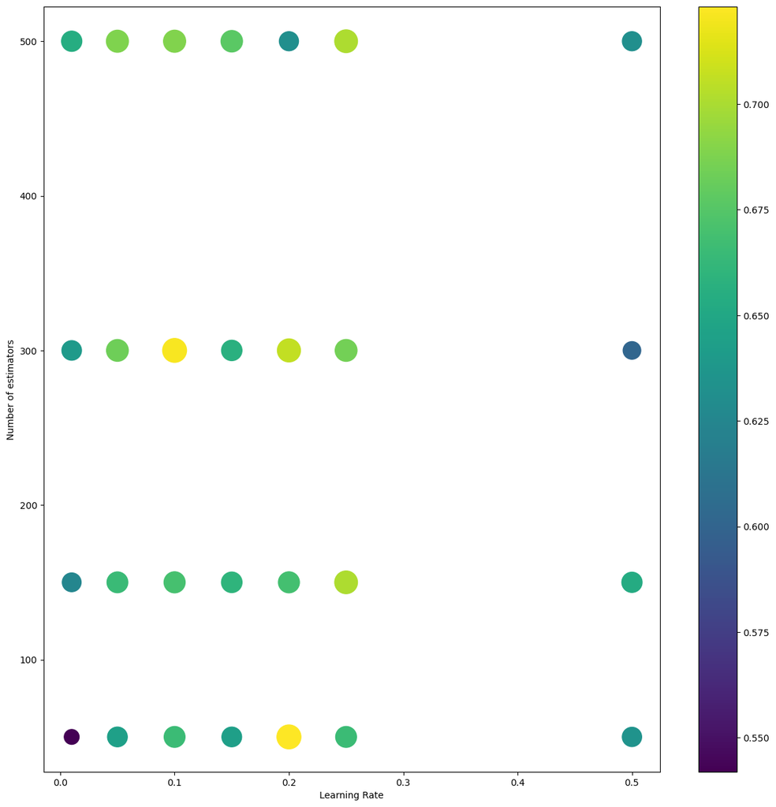

```python
import numpy as np
import matplotlib.pyplot as plt

colors = cv_results['mean_test_score']
area = (10*cv_results['mean_test_score'])**3.3

scatter = plt.scatter(cv_results['param_learning_rate'], cv_results['param_n_estimators'], s=area, c=colors)
plt.xlabel("Learning Rate")
plt.ylabel("Number of estimators")

plt.colorbar(scatter)

plt.show()
```

**8.1.** Perform forward stepwise selection on the dataset. Use the best parameters of the gradient boosting method obtained in **7.1.**.

```
Iterating for 1/31 features.
Iterating for 2/31 features.
Iterating for 3/31 features.
Iterating for 4/31 features.
Iterating for 5/31 features.
Iterating for 6/31 features.
Iterating for 7/31 features.
Iterating for 8/31 features.
Iterating for 9/31 features.
Iterating for 10/31 features.
Iterating for 11/31 features.
Iterating for 12/31 features.
Iterating for 13/31 features.
Iterating for 14/31 features.
Iterating for 15/31 features.
Iterating for 16/31 features.
Iterating for 17/31 features.
Iterating for 18/31 features.
Iterating for 19/31 features.
Iterating for 20/31 features.
Iterating for 21/31 features.
Iterating for 22/31 features.
Iterating for 23/31 features.
Iterating for 24/31 features.
Iterating for 25/31 features.
Iterating for 26/31 features.
Iterating for 27/31 features.
Iterating for 28/31 features.
Iterating for 29/31 features.
Iterating for 30/31 features.
Iterating for 31/31 features.
```

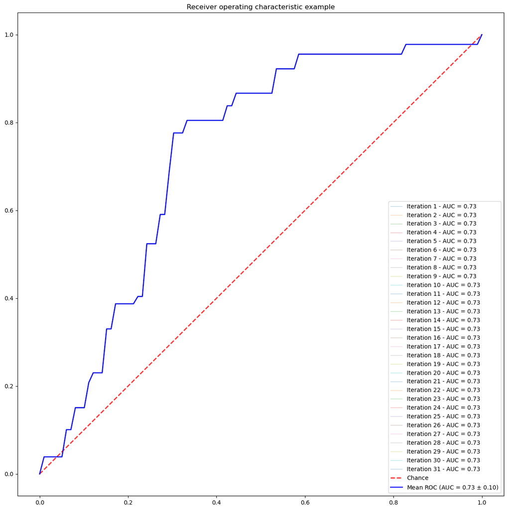

```python
import itertools
import statsmodels.api as sm

#Cross validation
kfold = KFold(n_splits=5, shuffle=True, random_state=0)

#Find best parameters
best_AUC = max(cv_results['mean_test_score'])
best_n_estimators = cv_results['param_n_estimators'][list(cv_results['mean_test_score']).index(max(cv_results['mean_test_score']))]
best_learning_rate = cv_results['param_learning_rate'][list(cv_results['mean_test_score']).index(max(cv_results['mean_test_score']))]

#Building best gradient boosting regressor
gbr =  GradientBoostingRegressor(n_estimators = best_n_estimators, learning_rate = best_learning_rate, max_depth = 2, random_state = 1)

fig, ax = plt.subplots()

tprs = []
aucs = []
mean_fpr = np.linspace(0,1,100)

predictors = []
sub_mean_tpr = [[] for i in range(X.shape[1] + 1)]
sub_mean_auc = [None for i in range(X.shape[1] + 1)]
sub_mean_std_auc = [None for i in range(X.shape[1] + 1)]

for k in range(1, X.shape[1] + 1):
    print('Iterating for {}/{} features.'.format(k, X.shape[1]))
    remaining_predictors = [p for p in X.columns if p not in predictors]
    models_best_forward_iter = pd.DataFrame(columns=['feature_single', "features", "rsq", "rss", "adjr2", 'aic', 'bic'])

    for i, (train,test) in enumerate(kfold.split(X,y)):
        gbr.fit(X.loc[train], y[train])
        y_proba = gbr.predict(X.loc[test])
        fpr, tpr, _ = roc_curve(y[test], y_proba[:])

        #Calculate mean fpr/tpr/auc for each iteration of the forward stepwise selection
        interp_tpr = np.interp(mean_fpr, fpr, tpr)
        interp_tpr[0] = 0.0

        tprs.append(interp_tpr)
        aucs.append(auc(fpr,tpr))

        sub_mean_tpr[k] = np.mean(tprs[-5:], axis=0)
        sub_mean_tpr[k][-1] = 1.0
        sub_mean_auc[k] = auc(mean_fpr, sub_mean_tpr[k])
        sub_mean_std_auc[k] = np.std(aucs[-5:])

    ax.plot(mean_fpr, sub_mean_tpr[k], label='Iteration ' + str(k) + ' - AUC = ' + str(np.round(sub_mean_auc[k],2)), lw=1, alpha=0.3)

# Plot mean roc curve auc
ax.plot([0, 1], [0, 1], linestyle="--", lw=2, color="r", label="Chance", alpha=0.8)

mean_tpr = np.mean(tprs, axis=0)
mean_tpr[-1] = 1.0
mean_auc = auc(mean_fpr, mean_tpr)
std_auc = np.std(aucs)

ax.plot(mean_fpr, mean_tpr, color="b", label=r"Mean ROC (AUC = %0.2f $\pm$ %0.2f)" % (mean_auc, std_auc), lw=2, alpha=0.8)
ax.set(xlim=[-0.05, 1.05], ylim=[-0.05, 1.05], title="Receiver operating characteristic example")
ax.legend(loc="lower right")
plt.rcParams['figure.figsize'] = [15, 15]

plt.show()
```

## 3) Theoretical Questions

**1.** Consider a dataset where best subset, forward stepwise and backward stepwise selection will be performed. For each of the 3 approaches, we obtain $p+1$ models, $p$ being the total number of predictors. This means that each approach has a model with 0 predictors, one with 1 predictor, one with 2 predictor, up until one model with $p$ predictors. Answer and justify the following questions:

**a)** Which of the three models with $k, \, \forall_{k \in [0,p]}$ predictors has the smallest training RSS?

In general, the model with k predictors that is selected using best subset selection will have the smallest training RSS among the three approaches for a given value of k. This is because best subset selection considers all possible models with k predictors and chooses the one with the lowest training RSS.

Forward stepwise selection and backward stepwise selection are both greedy algorithms that consider a limited set of models and choose the one that results in the lowest training RSS at each step. As a result, the model selected by either of these approaches may not necessarily have the lowest training RSS among all possible models with k predictors.

**b)** Which of the three models with $k, \, \forall_{k \in [0,p]}$ predictors has the smallest test RSS?

The model with the smallest test RSS is the one that fits the best to new data. In general, the model with the smallest test RSS will not necessarily be the same as the model with the smallest training RSS, since the latter may be overfit to the training data and not generalize well to new sets of data.

**c)** Evaluate the following statements with *true* or *false*. Justify your answers.

```
i. The predictors in the k-variable model identified by forward stepwise selection are a subset of the predictors in the (k+1)-variable model identified by forward stepwise selection.
```

True. In forward stepwise selection, the algorithm adds predictors to the previous best model. Therefore, a (k+1)-variable model will contain all the predictors in a k-variable model.

```
ii. The predictors in the k-variable model identified by backward stepwise selection are a subset of the predictors in the (k + 1)-variable model identified by backward stepwise selection.
```

True. In backward stepwise selection, the algorithm will progressively remove the least useful predictors, one by one. This means that a (k+1)-variable model will accomodate all predictors present in the next iteration of the backward stepwise selection (which will have a k-variable model).

```
iii. The predictors in the k-variable model identified by backward stepwise selection are a subset of the predictors in the (k + 1)-variable model identified by forward stepwise selection.
```

False. The forward and backward stepwise selection methods are independent from one another and the models produced by one don't have any relation to the models produced by the other.

```
iv. The predictors in the k-variable model identified by forward stepwise selection are a subset of the predictors in the (k+1)-variable model identified by backward stepwise selection.
```

False. The forward and backward stepwise selection methods are independent from one another and the models produced by one don't have any relation to the models produced by the other.

```
v. The predictors in the k-variable model identified by best subset selection are a subset of the predictors in the (k + 1)-variable model identified by best subset selection.
```

False. While that would be true for the forward and backward stepwise selection methods, because they are greedy, that is not the case with the best subset selection. A best subset selected model with k+1 variables doesn't necessarily contain all the k predictors in a k-variable model because the best subset selection method will go through every single possible model, choosing the best one among them.

**2.** Ridge regression tends to give similar coefficient values to correlated variables, whereas lasso regression may give substantially different coefficients to correlated variables. This questions explores this property in a simplified setting.

Suppose that $n=2$, $p=2$, $x_{11} = x_{12}$, $x_{21} = x_{22}$. Moreover, suppose that $y_1 + y_2 = 0$ and $x_{11} + x_{21} = 0$ and $x_{12} + x_{22} = 0$, meaning that the estimate for the intercept in a least squares, ridge regression, or lasso regression is zero: $\hat{\beta} = 0$.

**a)** Write the ridge regression optimization problem in this setting.

Simplifying the problem, we can define the following:

- $x_{11} = x_{12} = x_1$
- $x_{21} = x_{22} = x_2$

The ridge regression optimization seeks to minimize the following expression:

$\sum_{i=1}^{2} (y_i - \hat{\beta_0} - \sum_{j=1}^{2} \hat{\beta_j} x_{ij})^2 + \lambda \sum_{j=1}^{2} \hat{\beta_j}^2 \Leftrightarrow $

$\Leftrightarrow (y_1 - \hat{\beta_1} x_1 - \hat{\beta_2} x_1)^2 + (y_2 - \hat{\beta_1} x_2 - \hat{\beta_2} x_2)^2 + \lambda (\hat{\beta_1}^2 + \hat{\beta_2}^2) $

**b)** Prove that in this setting, the ridge regression coefficient estimates satisfy $\hat{\beta}_1 = \hat{\beta}_2$.

To solve the optimization problem, we need to calculate the partial derivatives in respect to $\hat{\beta}_1$ and $\hat{\beta_2}$. To simplify the calculations, we set $x_1 = a$ and $y_1 = b$, which implies that $x_2 = -a$ and $y_2 = -b$:

- $(4a^2 + 2\lambda)\hat{\beta_1} - 4ab + 4\hat{\beta_2}a^2 $
- $(4a^2 + 2\lambda)\hat{\beta_2} - 4ab + 4\hat{\beta_1}a^2 $

The above equations have equal value, so we can come to the conclusion that $\hat{\beta_1} = \hat{\beta_2}$.

**c)** Write the lasso regression optimization problem in this setting.

Using the same simplification as in question a), the lasso regression optimization seeks to minimize the following expression:

$\sum_{i=1}^{2} (y_i - \hat{\beta_0} - \sum_{j=1}^{2} \hat{\beta_j} x_{ij})^2 + \lambda \sum_{j=1}^{2} \vert \hat{\beta_j} \vert \Leftrightarrow $

$\Leftrightarrow (y_1 - \hat{\beta_1} x_1 - \hat{\beta_2} x_1)^2 + (y_2 - \hat{\beta_1} x_2 - \hat{\beta_2} x_2)^2 + \lambda (\vert \hat{\beta_1} \vert + \vert \hat{\beta_2} \vert) $

**d)** Prove that in this setting, the lasso regression coefficients $\hat{\beta}_1$ and $\hat{\beta}_2$ are not unique, meaning that there are many possible solutions to the optimization problem in (c). Describe these solutions.

Using the same simplifications as in questions a) and b), and calculating the partial derivatives in respect to $\hat{\beta}_1$ and $\hat{\beta_2}$ we get the same expression:

- $\pm \lambda + 4a(a(\hat{\beta_1} + \hat{\beta_2}) - b)$

Geometrically, the lasso regression solution corresponds to the intersection of points in the ($\hat{\beta_1}$,$\hat{\beta_2}$) plane that solve the equation above with the additional constraint that the sum of the absolute values of the coefficients is less than a fixed constant.

**3.** Draw an example of a partition of two-dimensional feature space that could result from recursive binary splitting. Your example should contain at least six regions. Draw a decision tree corresponding to this partition. Be sure to label all aspects of your figures, including the regions R1, R2,..., the cutpoints t1, t2,..., and so forth.

If you prefer you can draw it by hand or in any software and use a scan of it.

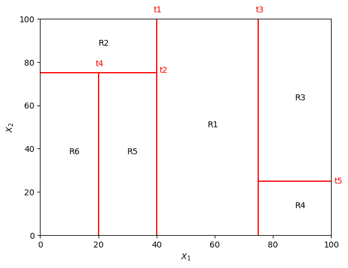

```python
import matplotlib.pyplot as plt

# Create a figure and a subplot
fig, ax = plt.subplots()

# Set the x and y limits of the plot
ax.set_xlim(0, 100)
ax.set_ylim(0, 100)

# Set the x and y labels of the plot
ax.set_xlabel("$X_1$")
ax.set_ylabel("$X_2$")

# Define the cutpoints
t1 = (40, 0, 40, 100, 1, 39, 95)
t2 = (0, 75, 40, 75, 2, 41, 67)
t3 = (75, 0, 75, 100, 3, 74, 95)
t4 = (20, 0, 20, 75, 4, 19, 70)
t5 = (75, 25, 100, 25, 5, 101, 16)

# Draw the lines and add the labels for the cutpoints
for t in [t1, t2, t3, t4, t5]:
    ax.plot([t[0], t[2]], [t[1], t[3]], c='red')
    ax.text(t[5], t[6] + 8, f"t{t[4]}", color='red')

# Add the labels for the regions
ax.text((40 + 75) / 2, 50, "R1")
ax.text(20, (100 + 75) / 2, "R2")
ax.text((75 + 100) / 2, (100 + 25) / 2, "R3")
ax.text((75 + 100) / 2, 25 / 2, "R4")
ax.text(30, 75 / 2, "R5")
ax.text(10, 75 / 2, "R6")

# Show the plot
plt.show()
```

[figure not shown]

**4.** In 2 dimensions, a linear decision boundary takes the form $\beta_0 + \beta_1 X_1 + \beta_2 X_2 = 0$. Consider a nn-linear decision boundary:

**a)** Sketch the curve

$$(1 + X_1)^2 + (2 - X_2)^2 = 4$$

Additionally, indicate on your sketch the set of points that verify the condition

$$(1 + X_1)^2 + (2 - X_2)^2 > 4$$

and the condition

$$(1 + X_1)^2 + (2 - X_2)^2 \leq 4$$

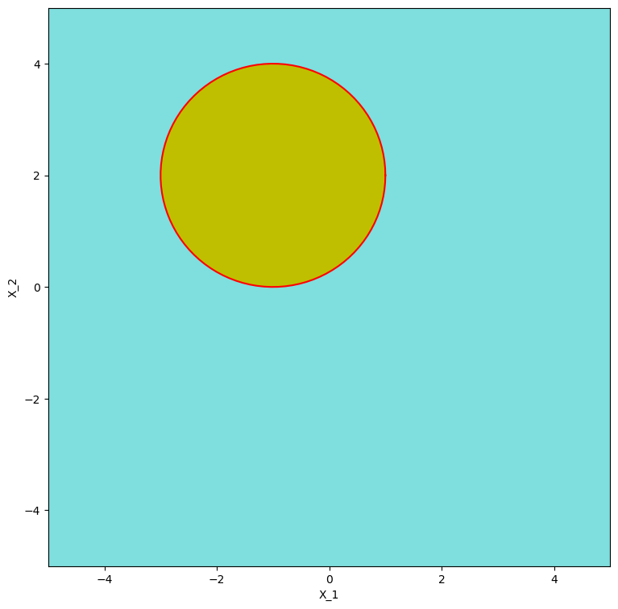

```python
import matplotlib.pyplot as plt
import numpy as np

#Base
fig,fg = plt.subplots()
fg.set_xlim(-5, 5)
fg.set_ylim(-5, 5)
plt.xlabel('X_1')
plt.ylabel('X_2')

#The first curve is a circle of radios 2 centered in (-1,2)
#to further paint the inside and outside of the circle lets define it as:
th = np.linspace(0,2*np.pi,100);
r = 2
Xcenter = -1
Ycenter = 2
X = np.cos(th)*r + Xcenter
Y = np.sin(th)*r + Ycenter
fg.plot(X, Y, color='r')

#external points to the circle
fg.fill([-5, 5, 5, -5], [-5, -5, 5, 5], 'c', alpha=0.5)

#internal points to the circle
fg.fill(X,Y, 'y', alpha=1)

plt.rcParams['figure.figsize'] = [9, 9]


plt.show()
```

The curve is drawn with the red colour. In a cyan colour are all the points that verify the condition: $$(1 + X_1)^2 + (2 - X_2)^2 > 4$$

In a yellow colour are all the points that verify the condition: $$(1 + X_1)^2 + (2 - X_2)^2 \leq 4$$

**b)** Suppose that a classifier assigns an observation to the blue class if $(1 + X_1)^2 + (2 - X_2)^2 > 4$ and to the red class otherwise. To what class are the following observations classified? (0,0), (-1,1), (2,2), (3,8)

The specified classifier will class the observations inside the circle or in its frontier as red and the ones outside of it will be classed as blue. This can be done in the following way:

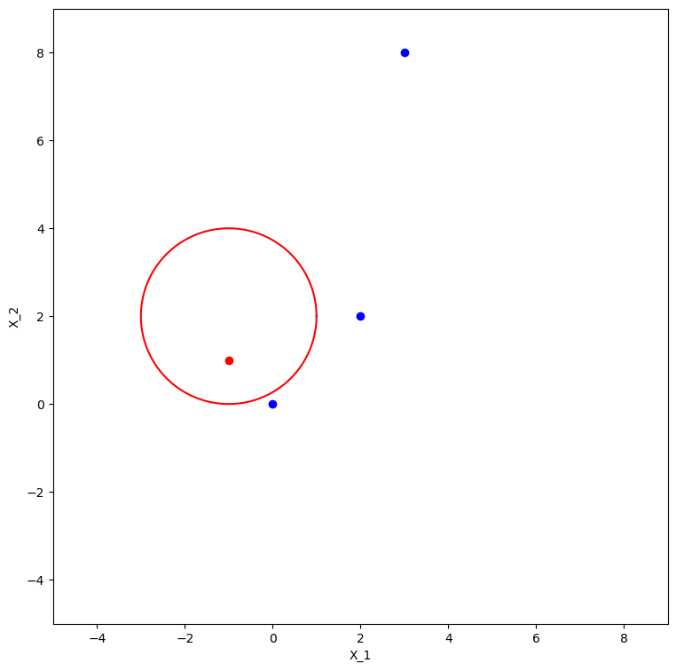

```python
import matplotlib.pyplot as plt
import numpy as np

#Base
fig,fg = plt.subplots()
fg.set_xlim(-5, 9)
fg.set_ylim(-5, 9)
plt.xlabel('X_1')
plt.ylabel('X_2')
fg.set_aspect(1)

th = np.linspace(0,2*np.pi,100);
r = 2
Xcenter = -1
Ycenter = 2
X = np.cos(th)*r + Xcenter
Y = np.sin(th)*r + Ycenter
fg.plot(X, Y, color='r')

#Process the given points
points = [[0,0],[-1,1],[2,2],[3,8]];

for i in points:
 value = (i[0]-Xcenter)**2 + (i[1]-Ycenter)**2;

 if value > 4:
     plt.scatter(i[0], i[1], color = 'blue')
 else:
     plt.scatter(i[0], i[1], color = 'red')

plt.rcParams['figure.figsize'] = [9, 9]

plt.show()
```

**c)** Prove that while the decision boundary in (b) is not linear in terms of $X_1$ and $X_2$, it is linear in terms of $X_1$, $X_1^2$, $X_2$, and $X_2^2$.

If we interpret our variables as being $X_1$, $X_1^2$, $X_2$, and $X_2^2$, we can say that this decision boundary is linear in relation to those terms. $X_1^2$ and $X_2^2$ are seen as terms in themselves which are not squared, something which would not happen if we were only trying to linearise the decision boundary in terms of $X_1$ and $X_2$. Therefore, the decision boundary $(1+X_1)^2+(2−X_2)^2=4$ is linear in terms of $X_1$, $X_1^2$, $X_2$, and $X_2^2$.

# 4) Laboratory Questions

What are the advantages and disadvantages of relational dabases versus graph databases, and when should one type be preferred over the other?

In order to understand when should we use relational databases or graph databases, we first need to properly understand what they have in common and in what they differ. Then from those differences infer the advantages and disadvantages of each one and concluding by determining in what situations each of them is best suited.

Despite both these databases being used to store and manage data, they differ in the way they represent and store data, as well as in the types of tasks they are best suited for. While relational databases are based on the relational model, which organizes data into tables of rows and columns, graph databases, on the other hand, are based on the graph model, which represents data as nodes and edges.

In the first type, each row represents a record, and each column represents a specific attribute or piece of data. They prove to be very good at storing structured data and for running queries on that data using structured query language (SQL) and are also good at enforcing data integrity through the use of constraints and transactions. Some of relational databases' advantages are summed up below.

Advantages:

• Widely used and understood (excellent support available) • Good at storing and querying structured data

Disadvantages:

• Not very user friendly when it comes to storing more complex and unorganized data • Unprepared to handle large volumes of data

In graph databases each node represents an entity, and each edge represents a relationship between two nodes. They are also proven to be quite good for storing and querying data that has complex relationships. Simmilarly as relational databases, some of graph databases' advantages are summed up below.

Advantages:

• Good at storing and querying complex, interconnected data • Support fast graph traversal queries

Disadvantages:

• Not as easy to understand and there may be fewer resources and support available • May not be as good at enforcing data integrity

Another aspect is that graph database can be easily sclaed horizontally whereas relational ones cannot. To sum up, relational databases are a good choice for storing and querying structured data, while graph databases are a good choice for storing and querying data with complex relationships. It's important to choose the right database, as using the wrong type of database can lead to performance issues and difficulty in scaling.